# Notes 3 - Exploratory Data Analysis

Linda Kukolich

January 26, 2015

# Clustering

Clustering organizes things that are **close** into groups. (Google: cluster analysis)

- How do we define close?
- How do we group things?
- How do we visualize the grouping?
- How do we interpret the grouping?

## Heirarchical clustering

- An agglomerative approach
  - Find closest two things
  - Put them together
  - Find next closest
- Requires
  - A defined distance
  - A merging approach
- Produces
  - A tree showing how close things are to each other
- How do we define close?
  - Distance or similarity
    - continuous - euclidean distance
    - continuous - correlation similarity
    - binary - manhattan distance
  - Pick a distance / similarity that makes sense for your problem

Example

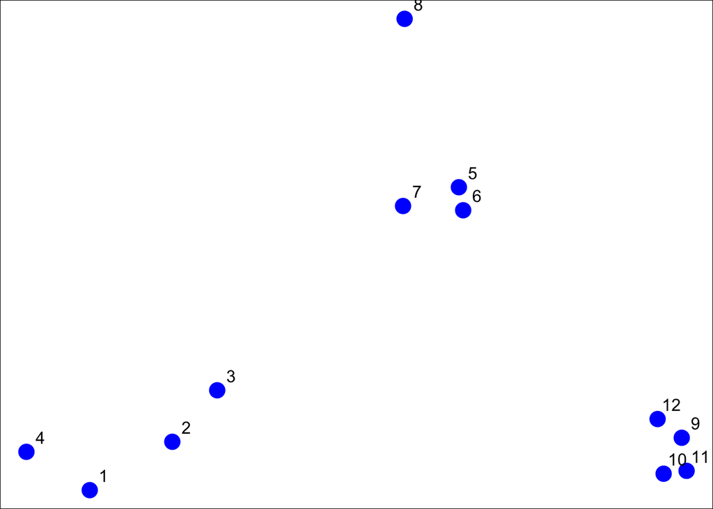

```r
set.seed(1234)
par(mar = c(0, 0, 0, 0))
x <- rnorm(12, mean = rep(1:3, each = 4), sd = 0.2)
y <- rnorm(12, mean = rep(c(1, 2, 1), each = 4), sd = 0.2)
plot(x, y, col = "blue", pch = 19, cex = 2)
text(x + 0.05, y + 0.05, labels = as.character(1:12))
```

### dist()

- Important parmeters: x, method

```r
dataFrame <- data.frame(x = x, y = y)
distxy <- dist(dataFrame)
distxy
```

```
##             1          2          3          4          5          6
## 2  0.34120511
## 3  0.57493739 0.24102750
## 4  0.26381786 0.52578819 0.71861759
## 5  1.69424700 1.35818182 1.11952883 1.80666768
## 6  1.65812902 1.31960442 1.08338841 1.78081321 0.08150268
## 7  1.49823399 1.16620981 0.92568723 1.60131659 0.21110433 0.21666557
## 8  1.99149025 1.69093111 1.45648906 2.02849490 0.61704200 0.69791931
## 9  2.13629539 1.83167669 1.67835968 2.35675598 1.18349654 1.11500116
## 10 2.06419586 1.76999236 1.63109790 2.29239480 1.23847877 1.16550201
## 11 2.14702468 1.85183204 1.71074417 2.37461984 1.28153948 1.21077373
## 12 2.05664233 1.74662555 1.58658782 2.27232243 1.07700974 1.00777231
##             7          8          9         10         11
## 2
## 3
## 4
## 5
## 6
## 7
## 8  0.65062566
## 9  1.28582631 1.76460709
## 10 1.32063059 1.83517785 0.14090406
## 11 1.37369662 1.86999431 0.11624471 0.08317570
## 12 1.17740375 1.66223814 0.10848966 0.19128645 0.20802789
```

He shows points and which clusters they belong to, but doesn’t give the code.

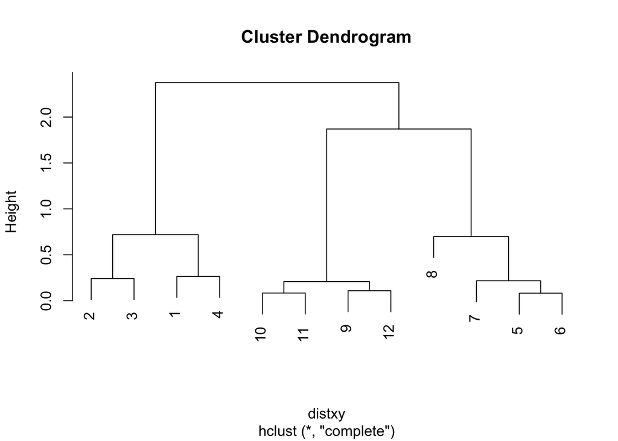

```r
hClustering <- hclust(distxy)
plot(hClustering)
```

Prettier dendrograms

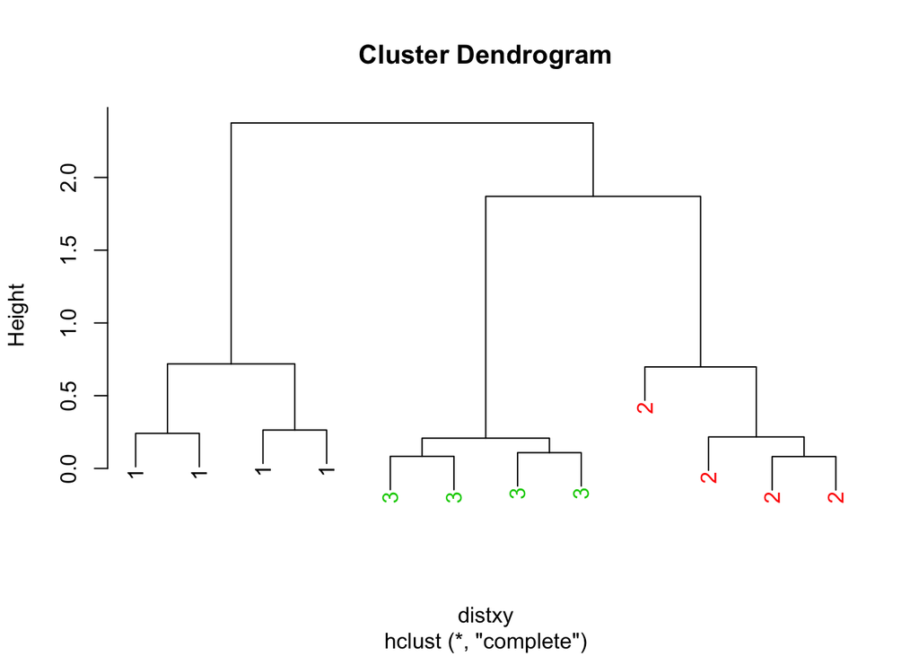

```r
myplclust <- function(hclust, lab = hclust$labels, lab.col = rep(1, length(hclust$labels)), hang = 0.1, ...) {
    ## modification of plclust for plotting hclust object *in color*! Copyright
    ## Eva KF Chan 2009 Arguments: hclust: hclust object lab: a character vector
    ## of labels of the leaves of the tree lab.col: color for the labels;
    ## NA=default device foreground color hand: as in hclust & pclust Side
    ## effect: A display of heirarchical cluster with colored leaf labels.
    y <- rep(hclust$height, 2)
    x <- as.numeric(hclust$merge)
    y <- y[which(x < 0)]
    x <- x[which(x < 0)]
    x <- abs(x)
    y <- y[order(x)]
    x <- x[order(x)]
    plot(hclust, labels = FALSE, hang = hang, ...)
    text(x = x, y = y[hclust$order] - (max(hclust$height) * hang), labels = lab[hclust$order], col = lab.col[hclust$order], srt = 90, adj = c(1, 0.5), xpd = NA, ...)
}
myplclust(hClustering, lab = rep(1:3, each = 4), lab.col = rep(1:3, each = 4))
```

There is an even pretties vesion on [http://gallery.r-enthusiasts.com/RGraphGallery.php?graph=79]

The points can be merged using “complete” (farthest apart two points in the clusters) or “average” (mean of the cluster elements)

### heatmap()

Runs hierarchical clustering on rows of table and columns of table.

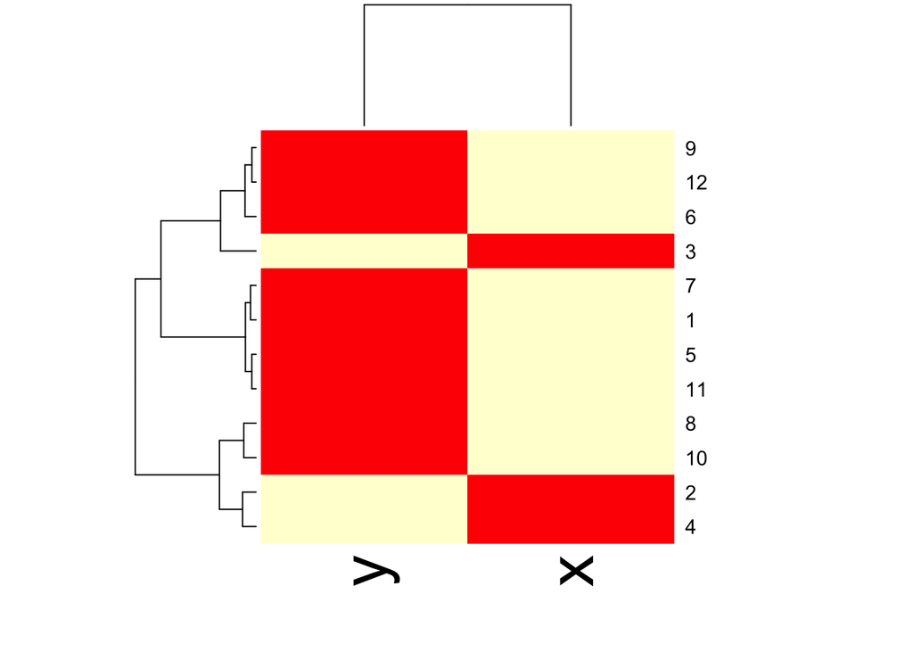

```r
set.seed(143)
dataMatrix <- as.matrix(dataFrame)[sample(1:12), ]
heatmap(dataMatrix)
```

### Notes and further resources

- Gives an idea of the relationships between variables/observations
- The picture may be unstable
  - change a few points
  - have different missing values
  - pick a different distance
  - change the merging strategy
  - change the scale of points for one variable
- but it is deterministic
- choosing where to cuts isn’t always obvious
- should be primarily used for exploration
- [Rafa’s Distances and Clustering Video](http://www.youtube.com/watch?v=wQhVWUcXM0A)
- [Elements of statistical learning](http://www-stat.stanford.edu/~tibs/ElemStatLearn/)

## K-Means Clustering

- A partitioning approach
  - Fix a number of clusters
  - Get “centroids” of each cluster
  - Assign things to closest centroid
  - Recalculate centroids
- Requires
  - A defined distance metric
  - A number of clusters
  - An initial guess as to cluster centroids
- Produces
  - Final estimate of cluster centroids
  - An assignment of each point to clusters

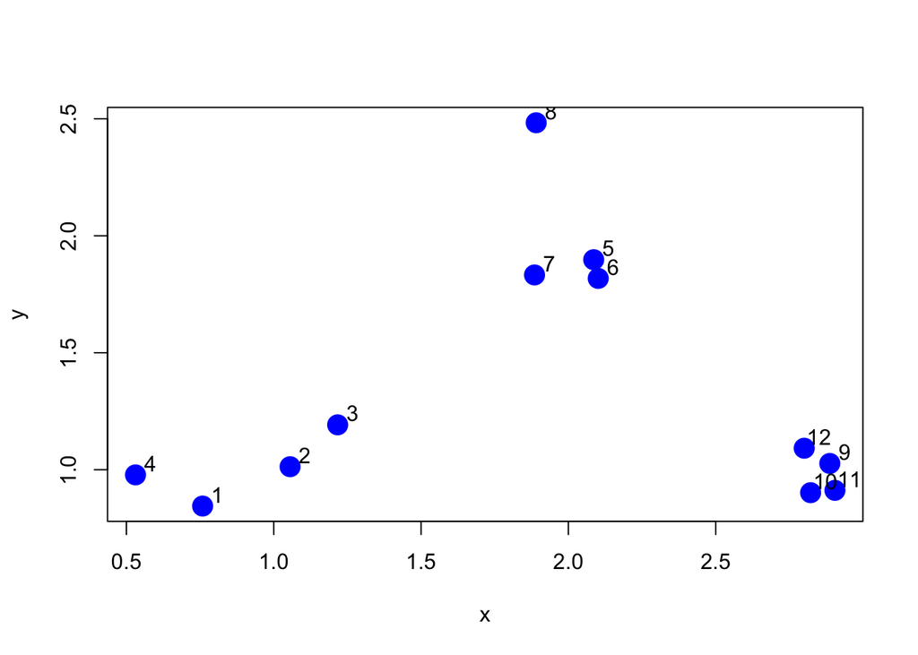

```r
plot(x, y, col = "blue", pch = 19, cex = 2)
text(x + 0.05, y + 0.05, labels = as.character(1:12))
```

Walks through a few iterations of clustering.

```r
kmeansObj <- kmeans(dataFrame, centers=3)
names(kmeansObj)
```

```
## [1] "cluster"      "centers"      "totss"        "withinss"
## [5] "tot.withinss" "betweenss"    "size"         "iter"
## [9] "ifault"
```

```r
kmeansObj$cluster
```

```
##  [1] 2 2 2 2 1 1 1 1 3 3 3 3
```

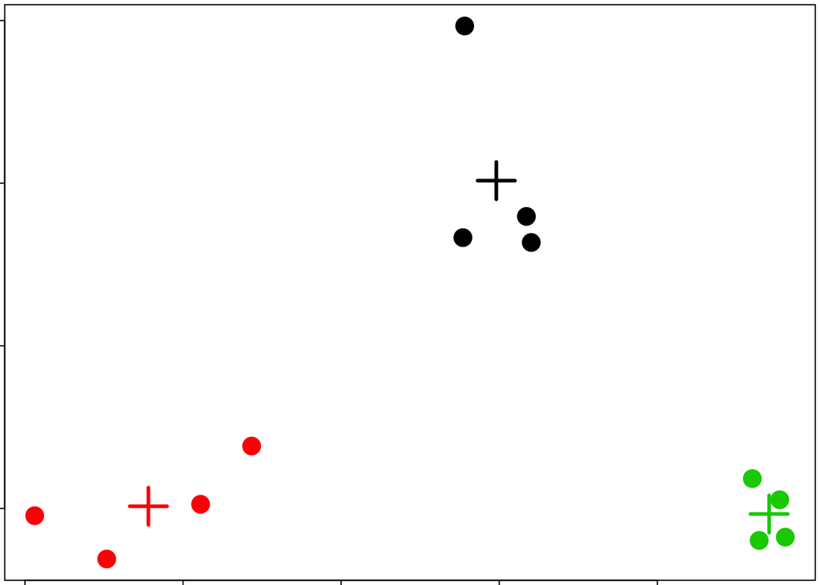

```r
par(mar = rep(0.2, 4))
plot(x, y, col = kmeansObj$cluster, pch = 19, cex = 2)
points(kmeansObj$centers, col = 1:3, pch = 3, cex = 3, lwd = 3)
```

### Heatmaps

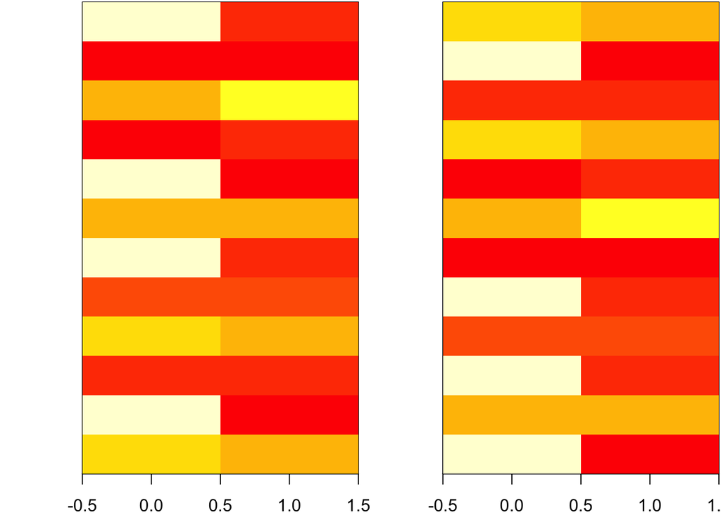

```r
kmeansObj2 <- kmeans(dataMatrix, centers = 3)
par(mfrow = c(1, 2), mar = c(2, 4, 0.1, 0.1))
image(t(dataMatrix)[, nrow(dataMatrix):1], yaxt = "n")
image(t(dataMatrix)[, order(kmeansObj$cluster)], yaxt = "n")
```

### Notes and further resources

- K-means requires a number of clusters
  - pick by eye / intuition
  - Pick by cross validation / information theory, etc.
  - [Determining the number of clusters](http://en.wikipedia.org/wiki/Determining_the_number_of_clusters_in_a_data_set)
- Kmeans is not deterministic
  - Different number of clusters
  - Different number of iterations
- [Rafael Irizarry’s Distances and Clustering Video](http://www.youtube.com/watch?v=wQhVWUcXM0A)
- [Elements of Statistical Learning](http://www-stat.stanford.edu/~tibs/ElemStatLearn/)

# Dimension Reduction (PCA and SVD)

Principal Components Analysis and Singular Value Decomposition

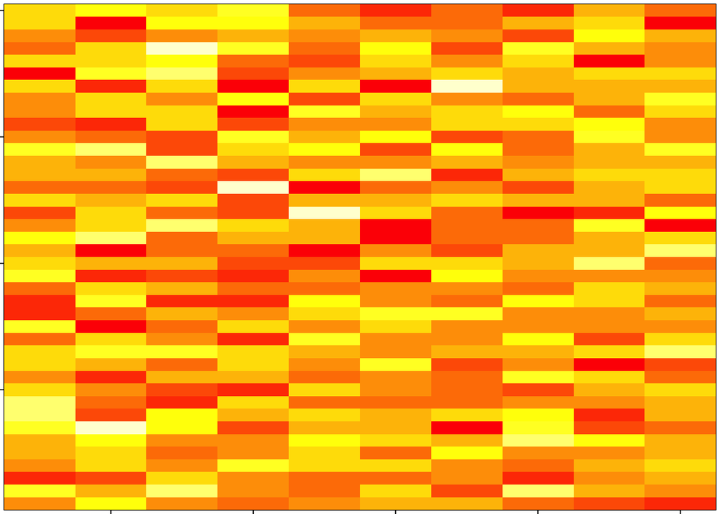

```r
set.seed(12345)
par(mar = rep(0.2, 4))
dataMatrix <- matrix(rnorm(400), nrow = 40)
image(1:10, 1:40, t(dataMatrix)[, nrow(dataMatrix):1])
```

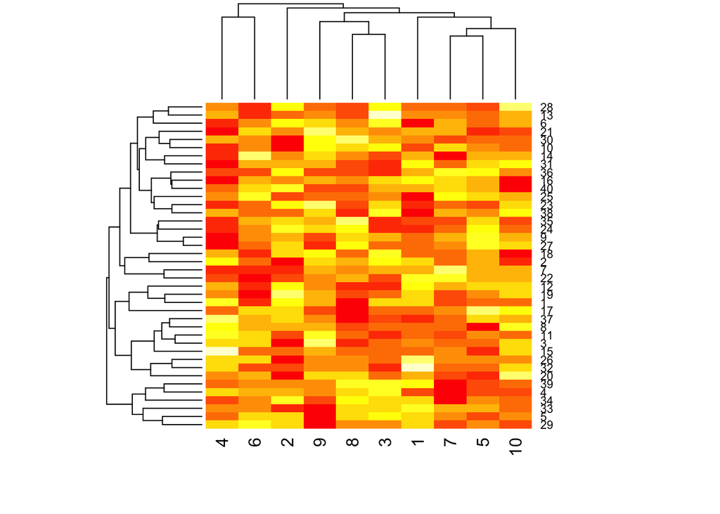

```r
# cluster the data
heatmap(dataMatrix)
```

No real structure here

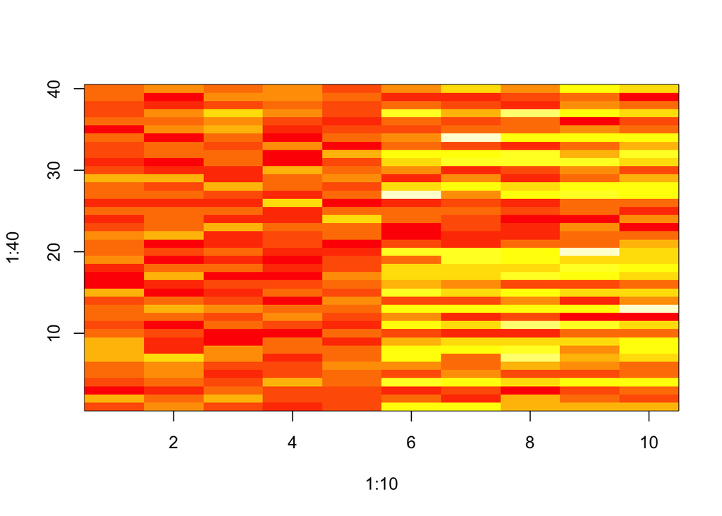

```r
# add a pattern
set.seed(67890)
for(i in 1:40) {
    # flip a coin
    coinFlip <- rbinom(1, size = 1, prob = 0.5)
    # if coin s heads, add a common pattern to that row
    if (coinFlip) {
        dataMatrix[i, ] <- dataMatrix[i, ] + rep(c(0,3), each = 5)
    }
}
image(1:10, 1:40, t(dataMatrix)[, nrow(dataMatrix):1])
```

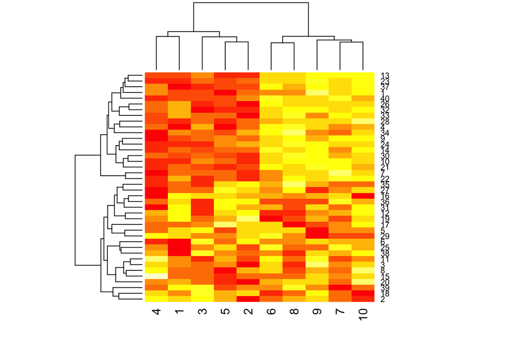

```r
heatmap(dataMatrix)
```

Now there is a pattern in one of the dimensions, not in the other.

### Patterns in rows and columns

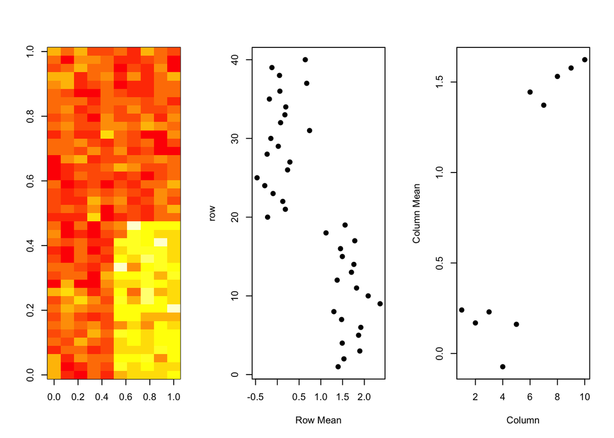

```r
hh <- hclust(dist(dataMatrix))
dataMatrixOrdered <- dataMatrix[hh$order, ]
par(mfrow = c(1, 3))
image(t(dataMatrixOrdered)[, nrow(dataMatrixOrdered):1])
plot(rowMeans(dataMatrixOrdered), 40:1, , xlab = "Row Mean", ylab = "row", pch = 19)
plot(colMeans(dataMatrixOrdered), xlab = "Column", ylab = "Column Mean", pch = 19)
```

### Related problems

You have multivariate variables X1,…,Xn so X1 = (X11, …, X1m) - Find a new set of multivariate variables that are uncorrelated and explain as much variance as possible - If you put all the variables together in one matrix, find the best matrix created with fewer variables (lower rank) that explains the original data.

The first goal is statistical and the second goal is **data compression**.

### Related Solutions - PCA / SVD

SVD

If is a matrix with each variable in a column and each observation in a row then the SVD is a “matrix decomposition”

$X = UDV^T$

where the columns of U are orthogonal (left singular vectors), the columns of V are orthogonal (right singular vectors) and D is a diagonal matrix (singular values).

PCA

The principal components are equal to the right singular values if you first scale the variables (subtract the mean, divide by the standard deviaion) (The V in the the matrix)

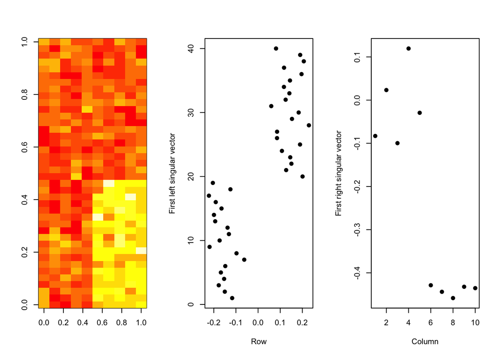

```r
svd1 <- svd(scale(dataMatrixOrdered))
par(mfrow = c(1, 3))
image(t(dataMatrixOrdered)[, nrow(dataMatrixOrdered): 1])
plot(svd1$u[, 1], 40:1, , xlab = "Row", ylab = "First left singular vector", pch = 19)
plot(svd1$v[, 1], xlab = "Column", ylab = "First right singular vector", pch = 19)
```

### Components of the SVD - Variance explained

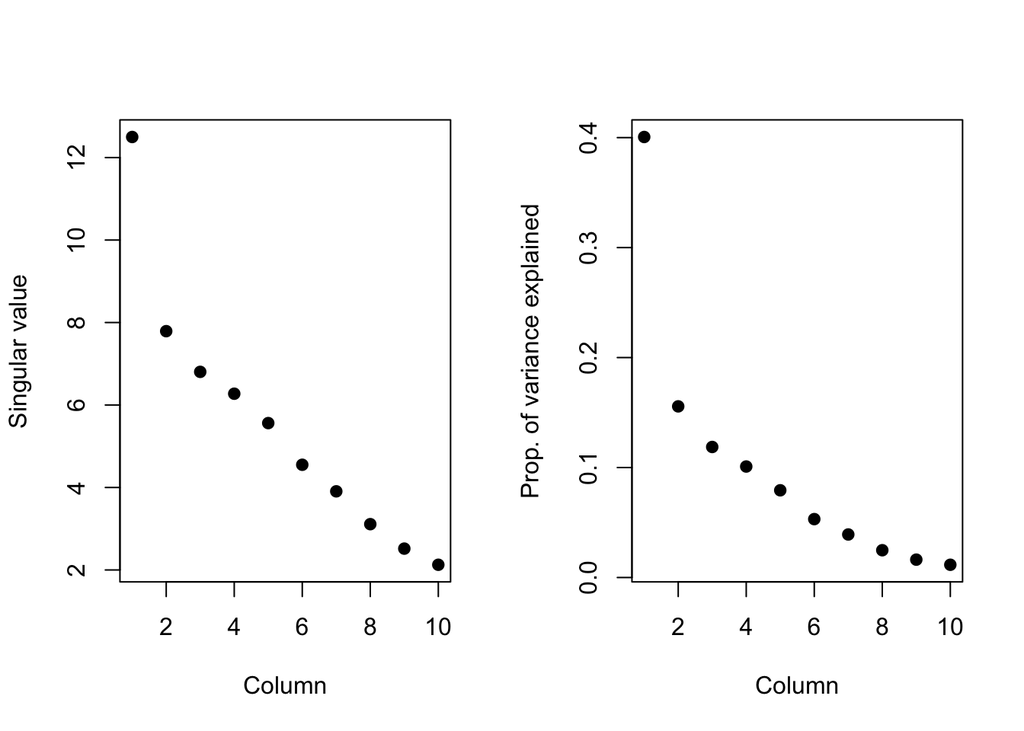

```r
par(mfrow = c(1, 2))
plot(svd1$d, xlab = "Column", ylab = "Singular value", pch = 19)
plot(svd1$d^2/sum(svd1$d^2), xlab = "Column", ylab = "Prop. of variance explained", pch = 19)
```

### Relationship to principal components

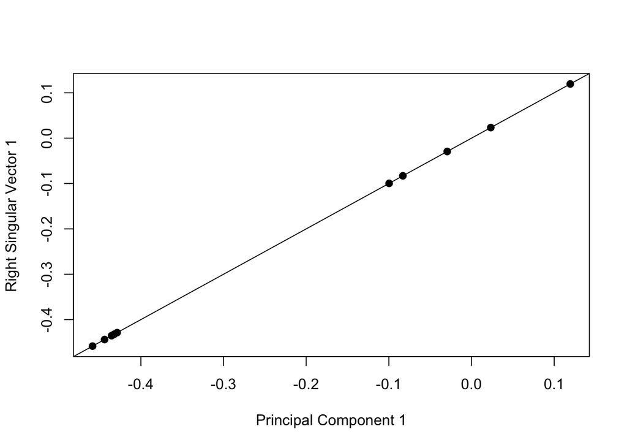

```r
svd1 <- svd(scale(dataMatrixOrdered))
pca1 <- prcomp(dataMatrixOrdered, scale = TRUE)
plot(pca1$rotation[, 1], svd1$v[, 1], pch = 19, xlab = "Principal Component 1", ylab = "Right Singular Vector 1")
abline(c(0, 1))
```

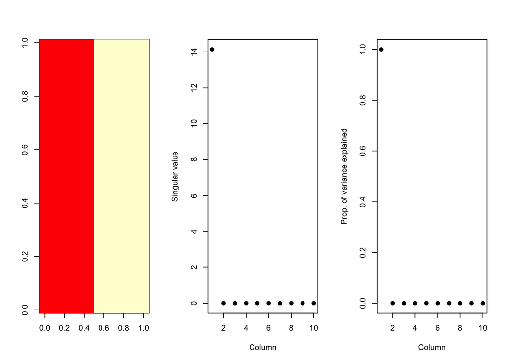

```r
constantMatrix <- dataMatrixOrdered*0
for(i in 1:dim(dataMatrixOrdered)[1]){constantMatrix[i, ] <- rep(c(0,1), each = 5)}
svd1 <- svd(constantMatrix)
par(mfrow = c(1, 3))
image(t(constantMatrix)[, nrow(constantMatrix):1])
plot(svd1$d, xlab="Column", ylab="Singular value", pch = 19)
plot(svd1$d^2/sum(svd1$d^2), xlab="Column", ylab = "Prop. of variance explained", pch = 19)
```

Adding a second pattern

```r
set.seed(678910)
for (i in 1:40) {
    # flip a coin
    coinFlip1 <- rbinom(1, size = 1, prob = 0.5)
    coinFlip2 <- rbinom(1, size =1, prob = 0.5)
    # if coin is heads add a common pattern to that row
    if (coinFlip1) {
        dataMatrix[i, ] <- dataMatrix[i, ] + rep(c(0, 5), each = 5)
    }
    if (coinFlip2) {
        dataMatrix[i, ] <- dataMatrix[i, ] + rep(c(0, 5), 5)
    }
}
hh <- hclust(dist(dataMatrix))
dataMatrixOrdered <- dataMatrix[hh$order, ]
```

### SVD true patterns

One side is lighter than the other, and alternating columns are lighter or darker.

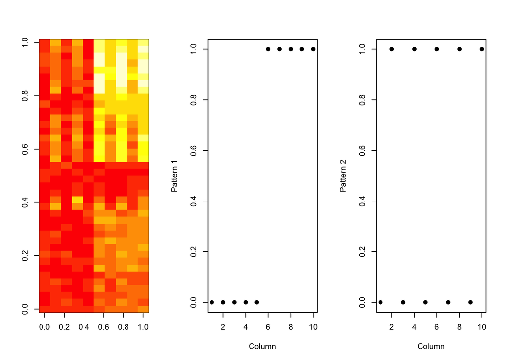

```r
svd2 <- svd(scale(dataMatrixOrdered))
par(mfrow = c(1, 3))
image(t(dataMatrixOrdered)[, nrow(dataMatrixOrdered):1])
plot(rep(c(0,1), each = 5), pch = 19, xlab = "Column", ylab = "Pattern 1")
plot(rep(c(0,1), 5), pch = 19, xlab = "Column", ylab = "Pattern 2")
```

### *v* and patterns of variance in rows

In the estimate, we see an intermingled pattern, up and down plus alternating, which is harder to see as a reader of the plot.

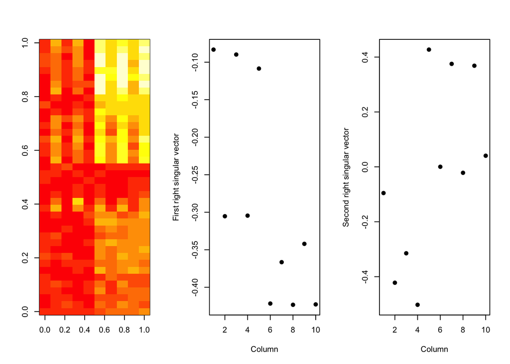

```r
par(mfrow = c(1, 3))
image(t(dataMatrixOrdered)[, nrow(dataMatrixOrdered):1])
plot(svd2$v[, 1], pch = 19, xlab = "Column", ylab = "First right singular vector")
plot(svd2$v[, 2], pch = 19, xlab = "Column", ylab = "Second right singular vector")
```

### *d* and variance explained

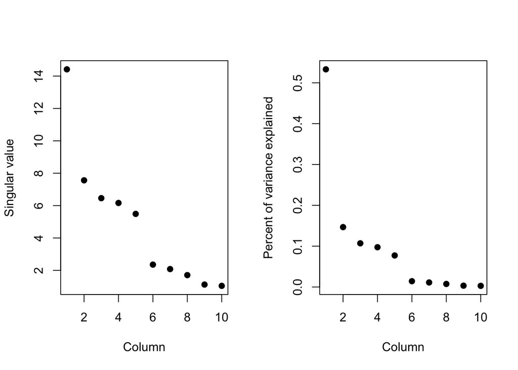

```r
svd1 <- svd(scale(dataMatrixOrdered))
par(mfrow = c(1, 2))
plot(svd1$d, xlab = "Column", ylab = "Singular value", pch = 19)
plot(svd1$d^2/sum(svd1$d^2), xlab = "Column", ylab = "Percent of variance explained", pch = 19)
```

### Missing values

```r
dataMatrix2 <- dataMatrixOrdered
## Randomly inserst some missing data
dataMatrix2[sample(1:100, size = 40, replace = FALSE)] <- NA
# svd1 <- svd(scale(dataMatrix2)) ## Doesn't work!
```

### Imputing {impute}

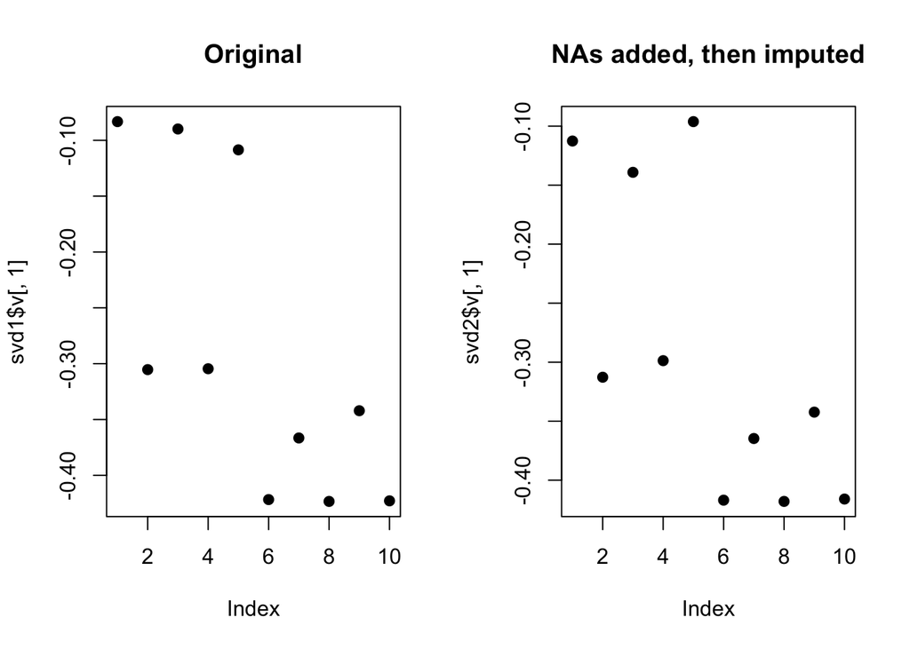

```r
library(impute) ## Available from http://bioconductor.org
dataMatrix2 <- dataMatrixOrdered
dataMatrix2[sample(1:100, size=40, replace=FALSE)] <- NA
dataMatrix2 <- impute.knn(dataMatrix2)$data
svd1 <- svd(scale(dataMatrixOrdered)); svd2 <- svd(scale(dataMatrix2))
par(mfrow=c(1, 2)); plot(svd1$v[,1], pch=19, main="Original"); plot(svd2$v[,1], pch=19, main="NAs added, then imputed")
```

There is an example working with a face, which uses data I do not have. ***How do I take a photo and then turn it to a matrix of numbers, -1 to 1?**

### Notes and further resources

- scale matters
- PC’s / SV’s may mix real patterns
- Can be computationally intensive
- [Advanced data analysis from an elementary point of view](http://www.stat.cmu.edu/~cshalizi/ADAfaEPoV/ADAfaEPoV.pdf)
- [Elements of statistical learning](http://www-stat.stanford.edu/~tibs/ElemStatLearn/)
- Alternatives
  - [Factor analysis](http://en.wikipedia.org/wiki/Factor_analysis)
  - [Independent components analysis](http://en.wikipedia.org/wiki/Independent_component_analysis)
  - [Latent semantic analysis](http://en.wikipedia.org/wiki/Latent_semantic_analysis)